# Consillium Academica

Kevin Andrés Leal Pérez

2024-07-12

# 1 TUTOR AUTOMÁTICO

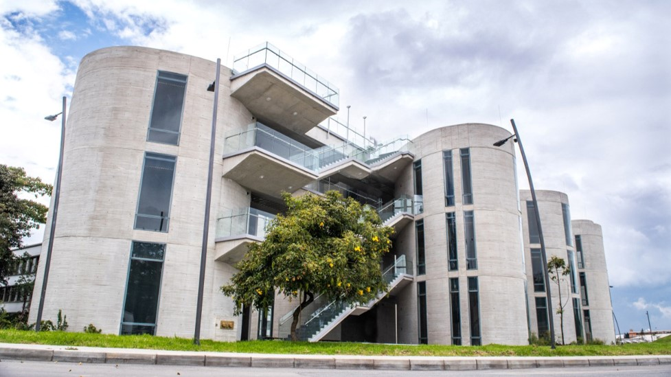

El proyecto tutor automático surge a partir de la iniciativa de la vicedecanatura académica de la Facultad de Ciencias de la Universidad Nacional de Colombia en querer agrupar a los estudiantes de pregrado en los programas curriculares de la facultad, a saber, Biología, Ciencias de la Computación, Estadística, Farmacia, Física, Geología, Matemáticas y Química. El objetivo de esta agrupación es, en un principio, utilizar la información de todos los estudiantes matriculados desde el primer semestre del 2012 hasta el primer semestre de 2022 y así, poder identificar un grupo de estudiantes que se caractericen por tener un desempeño académico inferior al común, cuya consecuencia puede ser la deserción académica o peor aún, la expulsión de la universidad por tener un promedio académico inferior a 3.0 en una escala de calificación de 0.0 a 5.0.

A continuación encontrá el tutorial de cómo llevar a cabo este análisis para que al final se obtenga una caracterización de los grupos de estudiantes en el semestre actual y un listado de los estudiantes a los que se deberá contactar.

# 2 Cargar las bases de datos

```r
# Importación datos
library(readr)
BASE <- read_csv("BASE_nueva.csv", col_types = cols(...1 = col_skip(), COD_PLAN = col_character(),
                                                    ACTIVO = col_factor(levels = c("0", "1"))))
```

# 3 Reducción de Dimensiones

Con la reducción de dimensiones se obtendrá mejores resultados para el agrupamiento, puesto que el método de análisis de componentes principales al tiempo que hace la reducción, reorganiza los datos permitiendo que los individuos similares se ubiquen juntos en la proyección.

```r
library("factoextra")
library("FactoMineR")

# Seleccionamos únicamente las variables cuantitativas
Agrupar <- BASE[,c(3:9)]

# ACP normado con variables fisicas
PCAestud=PCA(Agrupar, graph = F)
```

## 3.1 Determinar No. de Componentes

Con los 3 primeros ejes principales se retiene aproximadamente el 95% de la varianza y por lo tanto de la información completa de la base de datos. Mediante la tabla y el histograma de valores propios se aprecia que la adición del cuarto eje no aporta más información significativa. Por lo tanto, es suficiente realizar el método de agrupamiento sobre estas 3 variables artificiales.

```r
# valores propios y porcentajes acumulados por cada eje
get_eigenvalue(PCAestud)
```

```
##         eigenvalue variance.percent cumulative.variance.percent
## Dim.1 4.4317692282     63.310988975                    63.31099
## Dim.2 1.8582793647     26.546848067                    89.85784
## Dim.3 0.4075761145      5.822515921                    95.68035
## Dim.4 0.2524448153      3.606354505                    99.28671
## Dim.5 0.0378705760      0.541008229                    99.82772
## Dim.6 0.0116745666      0.166779523                    99.99450
## Dim.7 0.0003853346      0.005504779                   100.00000
```

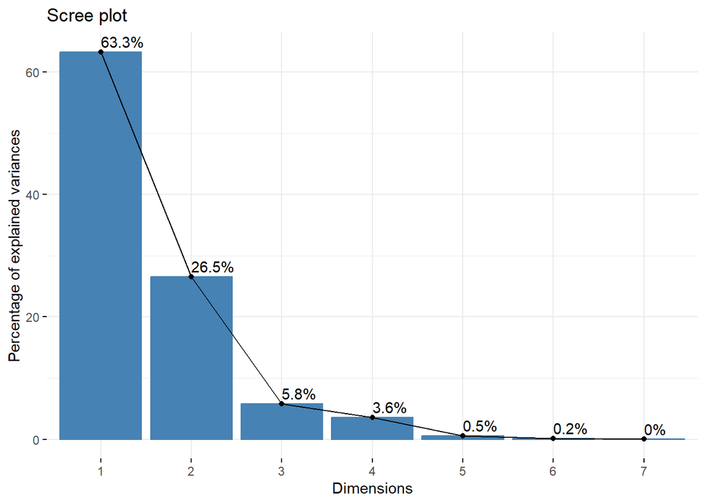

```r
# histograma de valores propios
fviz_eig(PCAestud, addlabels=T)
```

## 3.2 Primer Plano Factorial

A continuación se visualiza el primer plano factorial donde se utilizan las coordenadas en los primeros dos ejes.

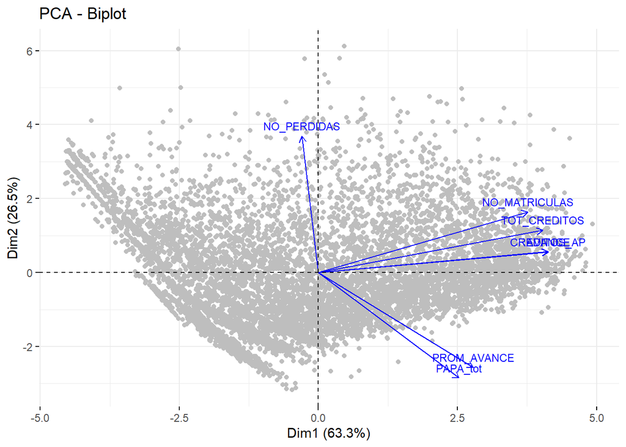

```r
# Gráfico
PCAestud2 <- PCAestud
PCAestud2$var$coord <- PCAestud2$var$coord*0.65
fviz_pca_biplot(PCAestud2, geom = "point", col.ind = "gray", col.var = "blue",labelsize= 3)
```

```r
# Guardamos las coordenadas de los estudiantes en los 3 ejes
coord <- as.data.frame(PCAestud$ind$coord[,1:3])
coord[,2] <- -coord[,2]
```

## 3.3 Interpretaciones de los Ejes

La variable del PAPA y el número de materias perdidas están mas correlacionadas con el eje 2 y están ubicadas en un sentido opuesto, mostrando que tienen una relación inversamente proporcional entre sí. Así, el segundo eje se establecería como una variable que mide el desempeño académico del estudiante. Por último, la variable del porcentaje de avance promedio por semestre está poco relacionada con cada uno de los 3 ejes principales, acercandose a valores de 0.4.

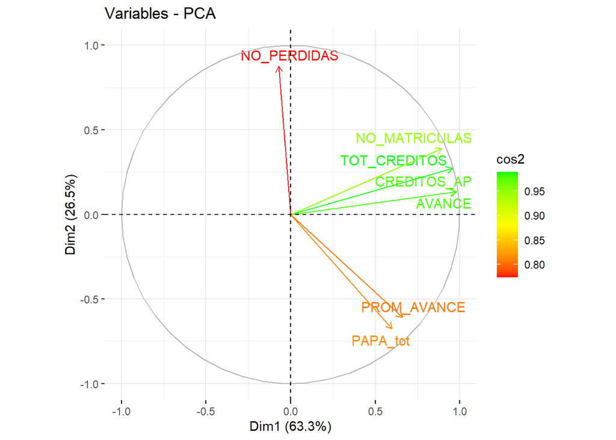

```r
# Círculo unitario con el color de la calidad de representación de las variables
fviz_pca_var(PCAestud,repel = T, col.var="cos2", gradient.cols=c("#FF0000","#FFFF00","#00FF00"))
```

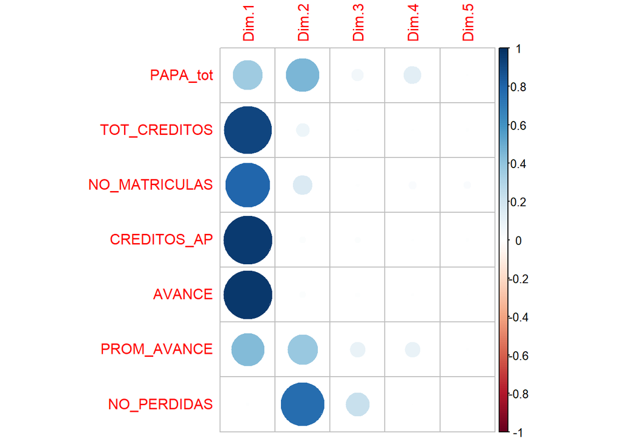

```r
# Matriz de correlaciones de las variables con los ejes
library(corrplot)
corrplot(get_pca_var(PCAestud)$cos2)
```

# 4 Agrupamiento con Fuzzy C-Means

Para lograr una mejoría en el tiempo de ejecución del algoritmo Fuzzy C-Means primero se ejecuta un K-Means, el cual proporcionará los centroides que servirán de puntos iniciales de los centros de los clusters en el Fuzzy C-Means.

## 4.1 Puntos de Inicialización

Con el método K-Means se determinó que el número óptimo de clusters era 6, puesto que proporcionaba una partición interesante y útil para los objetivos de la iniciativa. Además con 6 grupos se encontraba el último valor de cantidad de clústers que disminuía la distancia intra-clusters y por tanto su varianza de forma significativa.

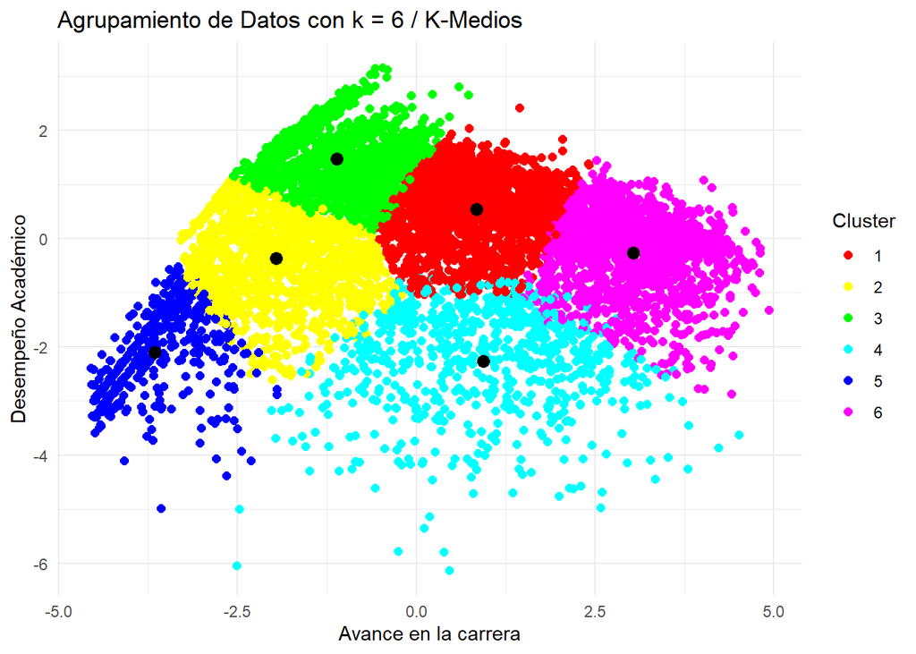

```r
# Establecemos una semilla para garantizar reproducibilidad
set.seed(21)

# Ejecutamos el K-Means con 6 grupos
k_means <- kmeans(coord, 6, nstart = 40)

# Gráfico del resultado sobre el primer plano factorial
library(ggplot2)
Cl_kmeans <-  as.factor(k_means$cluster)
ggplot() + geom_point(aes(x = Dim.1, y = Dim.2, color = Cl_kmeans), data = coord, size = 2) +
  scale_colour_manual(values=rainbow(6)) +
  geom_point(aes(x = k_means$centers[, 1], y = k_means$centers[, 2]), color = 'black', size = 3) +
  ggtitle('Agrupamiento de Datos con k = 6 / K-Medios') +
  xlab('Avance en la carrera') + ylab('Desempeño Académico') +
  labs(color="Cluster")+
  theme_minimal()
```

## 4.2 Ejecución del Algoritmo

```r
library(ppclust)

tictoc::tic()
ini.fcm <- fcm(coord, centers = k_means$centers, numseed = 21, m=2)
tictoc::toc()
```

```
## 137.55 sec elapsed
```

A continuación se presenta el resultado del clustering, que a simple vista es muy parecido al obtenido con K-Means. Sin embargo, ahora se cuenta con una matriz de probabilidades de pertenencia de cada registro a cada uno de los grupos.

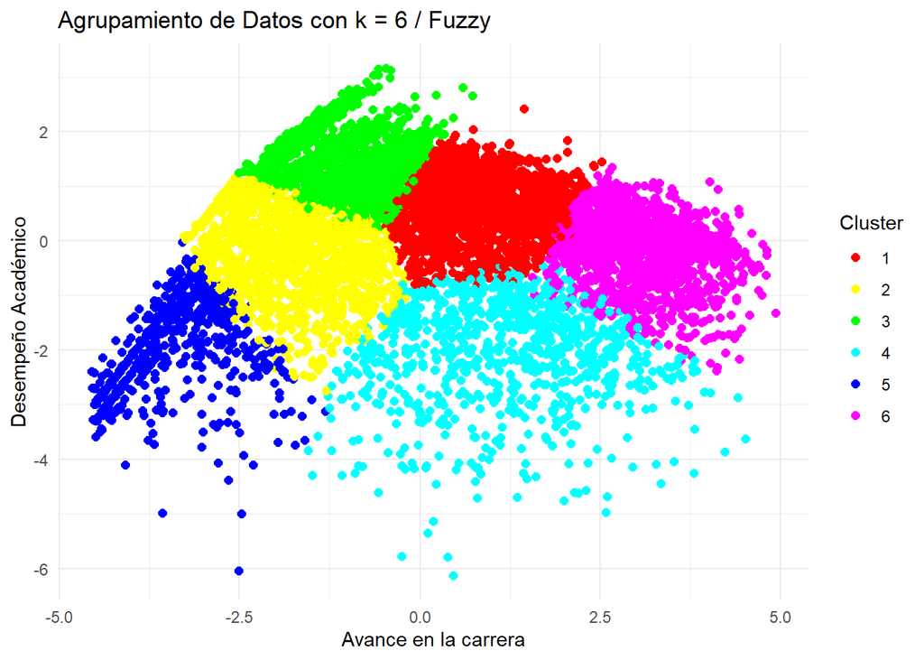

```r
Cluster <- as.factor(ini.fcm$cluster)
ggplot() + geom_point(aes(x = Dim.1, y = Dim.2, color = Cluster), data = coord, size = 2) +
  scale_colour_manual(values=rainbow(6)) +
  ggtitle('Agrupamiento de Datos con k = 6 / Fuzzy ') +
  xlab('Avance en la carrera') + ylab('Desempeño Académico') +
  labs(color="Cluster")+
  theme_minimal()
```

## 4.3 Interpretación de los grupos

```r
# Almacenamos la matriz de probabilidades de pertenencia
Fuzzy_matrix <- ini.fcm$u
# Creamos el vector de asignación de grupos tomando como límite 0.5
clust_tv <- crisp(Fuzzy_matrix, method = "threshold", tv=0.5)
# Calculamos la cantidad de individuos sin clasificar, cuya etiqueta será 0
sum(clust_tv==0)/nrow(BASE)*100
```

```
## [1] 26.24337
```

El gráfico de visualización del agrupamiento se muestra a continuación, aquí se aprecia que finalmente los individuos utilizados para la interpretación de los clusters son los más cercanos a sus respectivos centroides.

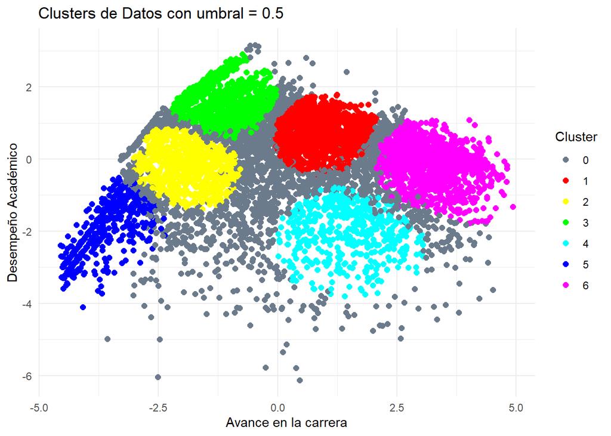

```r
colores <- c("#6C7B8B", rainbow(6))
ggplot() + geom_point(aes(x = Dim.1, y = Dim.2, color = as.factor(clust_tv)), data = coord, size = 2) +
  scale_colour_manual(values = colores) +
  ggtitle('Clusters de Datos con umbral = 0.5') +
  xlab('Avance en la carrera') + ylab('Desempeño Académico') +
  labs(color="Cluster")+
  theme_minimal()
```

### 4.3.1 Función para caracterización de los grupos

Para observar el comportamiento de los grupos se utilazará la siguiente función de análisis de clusters, que creará gráficos pertinentes para el análisis como se mostrará a continuación.

```r
analisis_clusters <- function(datos, cluster, ruido=F) {
  # Preparación de la base para facilidad en los códigos de los gráficos
  datos$cluster <- as.factor(cluster)
  datos$COD_PLAN <- factor(datos$COD_PLAN, labels = c("Bio", "Est", "Far", "Fís", "Geo", "Mat", "Quí", "Comp") )
  PAPAS    <- list()
  PERDIDA  <- list()
  PROM_AV  <- list()
  CREDITOS <- list()
  Frecuencias <- rep(NA,max(cluster))

  # División de variables cuantitativas y cualitativas
  clases <- sapply(datos,class)
  num <- clases == "numeric" | clases == "integer"
  text <- clases == "character" | clases == "factor"

  LIMITES  <- array(0, dim = c(3, sum(num), max(cluster) ) )
  dimnames(LIMITES) <- list(c("Q_05", "Q_50", "Q_90"), colnames(datos[,num]), 1:max(cluster))

  # Creación del vector de colores, el cual cambiará si el primer grupo tiene etiqueta 0 y corresponde a individuos sin clasificar
  if (ruido == T){
    colores <- c("#6C7B8B", rainbow(max(cluster)))
  }else{
    colores <- rainbow(max(cluster))
  }

  # Ciclo de creación de los boxplot del PAPA y materias perdidas para cada cluster
  for (i in 1:max(cluster)) {
    Tabla <- datos[datos$cluster==i,]
    Frecuencias[i] <- nrow(Tabla)
    LIMITES[,,i] <- apply(Tabla[,num], 2, function(X) quantile(X, c(0.05, 0.5, 0.95)))

    PAPAS[[i]] <- ggplot(Tabla, aes(x=COD_PLAN, y=PAPA_tot, fill= COD_PLAN ))+
      geom_boxplot()+
      stat_boxplot(geom = "errorbar", width = 0.25)+
      xlab("PROGRAMA")+ ylab("PAPA")+
      ylim(0,5)+
      ggtitle(paste0("Cluster ",i))+
      theme_minimal()+
      theme(legend.position = "none")

    PERDIDA[[i]] <- ggplot(Tabla, aes(x=COD_PLAN, y=NO_PERDIDAS, fill= COD_PLAN ))+
      geom_boxplot()+
      stat_boxplot(geom = "errorbar", width = 0.25)+
      xlab("PROGRAMA")+ ylab(" No. Perdidas")+
      ylim(0,max(datos$NO_PERDIDAS))+
      ggtitle(paste0("Cluster ",i))+
      theme_minimal()+
      theme(legend.position = "none")

    PROM_AV[[i]] <- ggplot(Tabla, aes(x=COD_PLAN, y=PROM_AVANCE, fill= COD_PLAN ))+
      geom_boxplot()+
      stat_boxplot(geom = "errorbar", width = 0.25)+
      xlab("PROGRAMA")+ ylab("Avance Semestre Promedio")+
      ylim(0,max(datos$PROM_AVANCE))+
      ggtitle(paste0("Cluster ",i))+
      theme_minimal()+
      theme(legend.position = "none")

    CREDITOS[[i]] <- ggplot(Tabla, aes(x=COD_PLAN, y=CREDITOS_AP, fill= COD_PLAN ))+
      geom_boxplot()+
      stat_boxplot(geom = "errorbar", width = 0.25)+
      xlab("PROGRAMA")+ ylab("Créditos Aprobados")+
      ylim(0,max(datos$CREDITOS_AP))+
      ggtitle(paste0("Cluster ",i))+
      theme_minimal()+
      theme(legend.position = "none")
  }

  # Gráficos para comparar el comportamiento general de los clusters en distintas variables
  Avance <- ggplot(datos, aes(y=AVANCE, x=NO_MATRICULAS, color=cluster) )+
    geom_point()+
    scale_colour_manual(values=colores) +
    ggtitle("Diagrama de Dispersión del Avance de Carrera")+
    labs(color="Cluster")+
    theme_minimal()

  PAPA_GEN <- ggplot(datos, aes(x=cluster, y=PAPA_tot, fill= cluster ))+
    geom_boxplot()+
    scale_fill_manual(values =colores)+
    stat_boxplot(geom = "errorbar", width = 0.25)+
    xlab("GRUPO")+ ylab("PAPA")+
    theme_minimal()+
    theme(legend.position = "none")

  PERD_GEN <- ggplot(datos, aes(x=cluster, y=NO_PERDIDAS, fill= cluster ))+
    geom_boxplot()+
    scale_fill_manual(values =colores)+
    stat_boxplot(geom = "errorbar", width = 0.25)+
    xlab("GRUPO")+ ylab("No. Perdidas")+
    theme_minimal()+
    theme(legend.position = "none")

  return(list(PAPAS=PAPAS, PAPA_GEN=PAPA_GEN, Avance=Avance, PERDIDA=PERDIDA,
              PERD_GEN=PERD_GEN, PROM_AV=PROM_AV, CREDITOS=CREDITOS,
              LIMITES=LIMITES, FREC=Frecuencias) )
}
```

Esta función recibe como primer parámetro la base de datos que almacena la información de todas las variables académicas, el segundo parámetro es el vector que contiene el grupo al que pertenece cada registro y por último, el parámetro *ruido* para indicar si hay un conjunto de datos que no se encuentra clasificado para que de esta manera sean representados con un color diferente o no se incluyan dentro de algunos de los gráficos.

```r
Int.total <- analisis_clusters(BASE, clust_tv, ruido = T)
# Podemos ver la cantidad de individuos dentro de cada grupo
Int.total$FREC
```

```
## [1] 1242  918 1451  496  532 1204
```

Para un análisis superficial se puede visualizar un diagrama de dispersión entre las variables del número de matrículas y el porcentaje de avance de los estudiantes, donde el color del punto indica el cluster al que pertenecen, adicionalmente se grafica un diagrama de caja para ver la distribución del PAPA y la cantidad de asignaturas reprobadas en cada cluster.

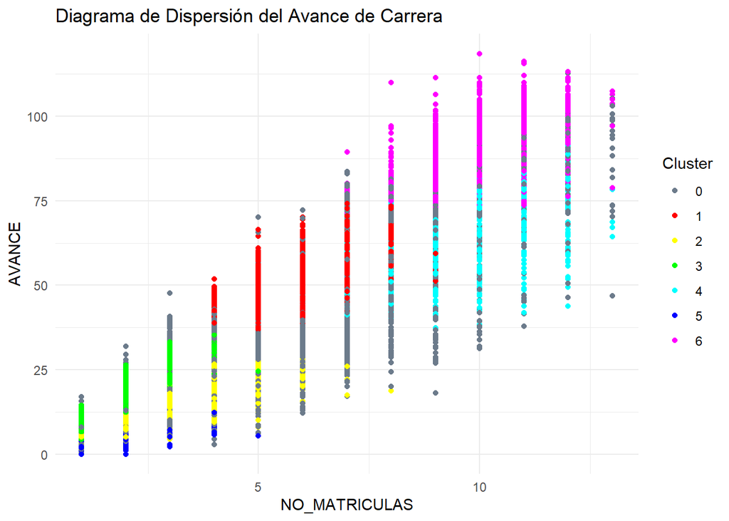

```r
# Grilla ggplot
library(gridExtra)
# Gráficos generales
Int.total$Avance
```

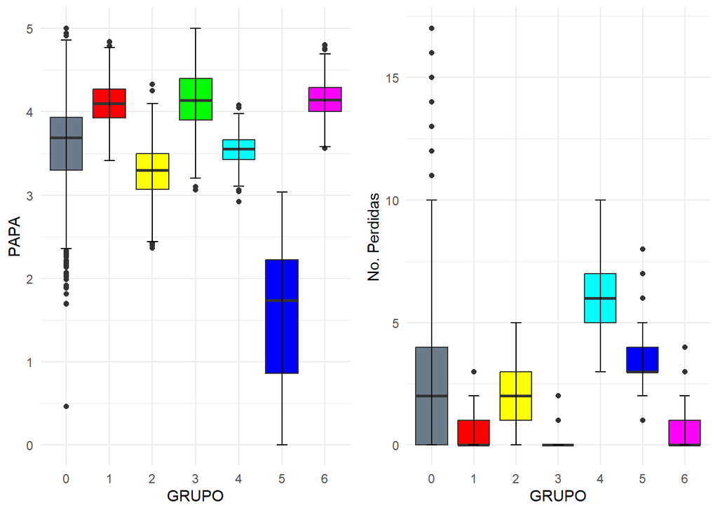

```r
grid.arrange(Int.total$PAPA_GEN, Int.total$PERD_GEN, ncol=2)
```

También se puede ver un comportamiento más detallado de las variables mediante un diagrama de caja dentro de cada cluster para cada programa curricular graficando las variables de PAPA y la cantidad de asignaturas reprobadas.

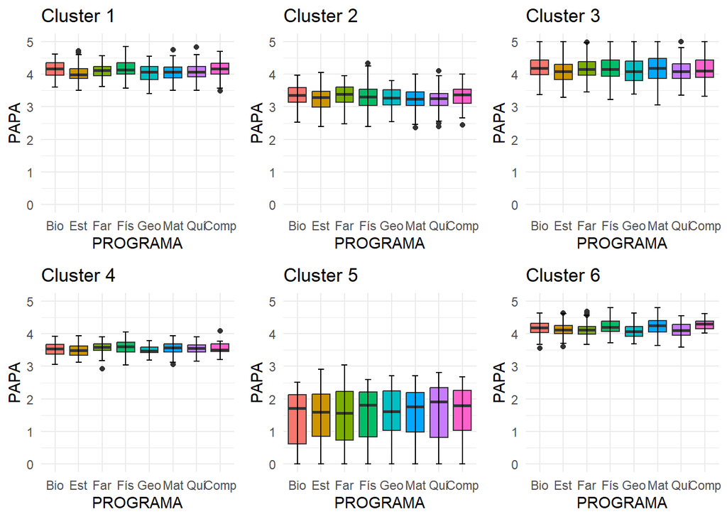

```r
grid.arrange( Int.total$PAPAS[[1]],Int.total$PAPAS[[2]],Int.total$PAPAS[[3]],
              Int.total$PAPAS[[4]],Int.total$PAPAS[[5]],Int.total$PAPAS[[6]], ncol=3)
```

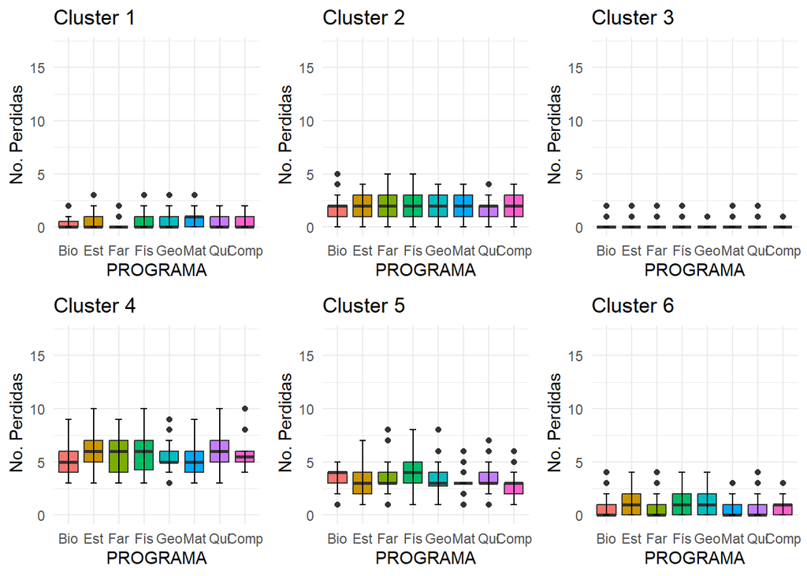

```r
grid.arrange( Int.total$PERDIDA[[1]],Int.total$PERDIDA[[2]],Int.total$PERDIDA[[3]],
              Int.total$PERDIDA[[4]],Int.total$PERDIDA[[5]],Int.total$PERDIDA[[6]], ncol=3)
```

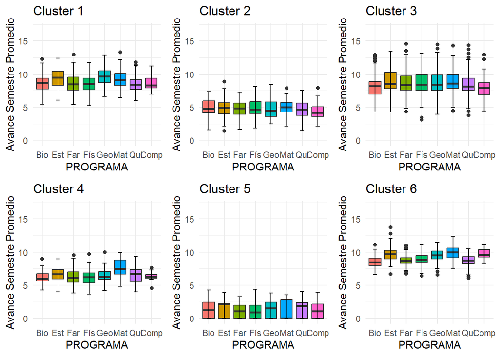

```r
grid.arrange( Int.total$PROM_AV[[1]],Int.total$PROM_AV[[2]],Int.total$PROM_AV[[3]],
              Int.total$PROM_AV[[4]],Int.total$PROM_AV[[5]],Int.total$PROM_AV[[6]], ncol=3)
```

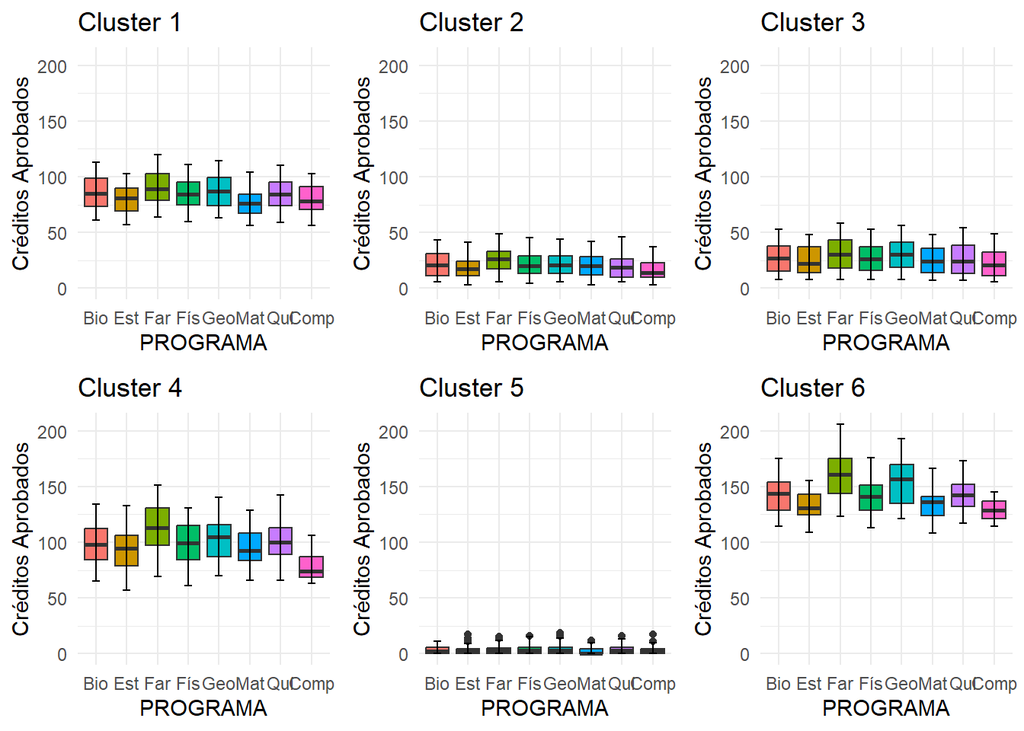

```r
grid.arrange( Int.total$CREDITOS[[1]],Int.total$CREDITOS[[2]],Int.total$CREDITOS[[3]],
              Int.total$CREDITOS[[4]],Int.total$CREDITOS[[5]],Int.total$CREDITOS[[6]], ncol=3)
```

Gracias al análisis presentado hasta el momento, se aprecian importantes diferencias entre los grupos resultantes lo que permite establecer una jerarquía para la priorización en la atención que requieren los estudiantes de la facultad, emulando lo que se conoce como un triage en el servicio de urgencias hospitalarias, que en este caso definimos como *Triage Académico*.

# 5 Triage Académico

## 5.1 Triage 1: Riesgo Alto

Este grupo es el más diferente de los demás pues representa a todas las personas que pierden su calidad de estudiantes en la universidad por su pésimo desempeño académico ya que su PAPA se mueve entre 0.0 y 2.6 en general, o en algunos casos hasta 3.0 explicando que hayan estudiantes que logran continuar hasta la tercera matrícula. Así, el avance es de 0 o solo hasta un 8% de la carrera y todo esto se refleja, además, en una alta cantidad de materias perdidas en apenas pocos semestres.

```r
knitr::kable(Int.total$LIMITES[,,5], digits = 1, align = "c")
```

|  | PAPA_tot | TOT_CREDITOS | NO_MATRICULAS | CREDITOS_AP | AVANCE | PROM_AVANCE | NO_PERDIDAS |
| --- | --- | --- | --- | --- | --- | --- | --- |
| Q_05 | 0.0 | 8 | 1 | 0 | 0.0 | 0.0 | 1 |
| Q_50 | 1.7 | 14 | 1 | 3 | 1.8 | 1.1 | 3 |
| Q_90 | 2.5 | 29 | 3 | 12 | 7.9 | 3.2 | 5 |

## 5.2 Triage 2: Riesgo Medio

```r
knitr::kable(Int.total$LIMITES[,,2], digits = 1, align = "c")
```

|  | PAPA_tot | TOT_CREDITOS | NO_MATRICULAS | CREDITOS_AP | AVANCE | PROM_AVANCE | NO_PERDIDAS |
| --- | --- | --- | --- | --- | --- | --- | --- |
| Q_05 | 2.7 | 11 | 1 | 7 | 4.3 | 2.9 | 0 |
| Q_50 | 3.3 | 27 | 3 | 20 | 12.5 | 4.8 | 2 |
| Q_90 | 3.8 | 48 | 5 | 39 | 25.5 | 6.8 | 4 |

## 5.3 Triage 3: Riesgo Bajo

```r
knitr::kable(Int.total$LIMITES[,,4], digits = 1, align = "c")
```

|  | PAPA_tot | TOT_CREDITOS | NO_MATRICULAS | CREDITOS_AP | AVANCE | PROM_AVANCE | NO_PERDIDAS |
| --- | --- | --- | --- | --- | --- | --- | --- |
| Q_05 | 3.2 | 91 | 7 | 70 | 43.8 | 4.6 | 3 |
| Q_50 | 3.6 | 119 | 10 | 100 | 62.5 | 6.4 | 6 |
| Q_90 | 3.9 | 154 | 12 | 133 | 81.6 | 8.6 | 9 |

## 5.4 Triage 4: Consillium Bajo

```r
knitr::kable(Int.total$LIMITES[,,3], digits = 1, align = "c")
```

|  | PAPA_tot | TOT_CREDITOS | NO_MATRICULAS | CREDITOS_AP | AVANCE | PROM_AVANCE | NO_PERDIDAS |
| --- | --- | --- | --- | --- | --- | --- | --- |
| Q_05 | 3.6 | 11 | 1 | 11.0 | 6.6 | 5.7 | 0 |
| Q_50 | 4.1 | 28 | 2 | 27.0 | 16.6 | 8.4 | 0 |
| Q_90 | 4.8 | 50 | 4 | 49.5 | 30.9 | 11.4 | 1 |

## 5.5 Triage 5: Consillium Medio

```r
knitr::kable(Int.total$LIMITES[,,1], digits = 1, align = "c")
```

|  | PAPA_tot | TOT_CREDITOS | NO_MATRICULAS | CREDITOS_AP | AVANCE | PROM_AVANCE | NO_PERDIDAS |
| --- | --- | --- | --- | --- | --- | --- | --- |
| Q_05 | 3.7 | 65 | 4 | 64 | 39.8 | 6.8 | 0 |
| Q_50 | 4.1 | 86 | 6 | 84 | 52.5 | 8.8 | 0 |
| Q_90 | 4.5 | 109 | 8 | 109 | 67.5 | 11.0 | 2 |

## 5.6 Triage 6: Consillium Alto

```r
knitr::kable(Int.total$LIMITES[,,6], digits = 1, align = "c")
```

|  | PAPA_tot | TOT_CREDITOS | NO_MATRICULAS | CREDITOS_AP | AVANCE | PROM_AVANCE | NO_PERDIDAS |
| --- | --- | --- | --- | --- | --- | --- | --- |
| Q_05 | 3.8 | 123 | 8 | 121 | 73.5 | 7.5 | 0 |
| Q_50 | 4.1 | 148 | 10 | 144 | 89.6 | 8.9 | 0 |
| Q_90 | 4.5 | 186 | 12 | 182 | 105.4 | 10.7 | 3 |

# 6 Identificación de Estudiantes en Riesgo

Finalmente los grupos que requieren de atención de su profesor tutor con mayor urgencia son los Triages 1 y 2 donde el primero corresponde a los estudiantes que son expulsados del programa por su mal desempeño académico y el segundo correspondiente a los estudiantes que apenas empiezan su recorrido por la universidad y que tienen un PAPA apenas superior del límite de pérdida del cupo en el programa. Sin embargo, acá también encontramos estudiantes con un desempeño académico aceptable, por lo cual sería necesario establecer un límite en la nota del PAPA para escoger los que de verdad requieren esta asistencia.

Puesto que deseamos tener el alcance de ayudar a todos los estudiantes que lo requieran, pueden existir casos en los que un estudiante se ubique en el lado opuesto de la frontera de estos grupos y se clasifique dentro de los grupos a los que no se les dará atención, así que podemos mover el umbral a un nivel más bajo para que se amplie el rango de cobertura de estos dos grupos como se muestra a continuación

```r
# Ampliación de la cobertura de los Triage 1 y 2
Clust_aum <- ini.fcm$cluster
Clust_aum[which(Fuzzy_matrix[,2]>0.2)] <- 2 # Triage 2
Clust_aum[which(Fuzzy_matrix[,5]>0.2)] <- 5 # Triage 1
```

A continuación se observa nuevamente la asignación de los grupos para todos los estudiantes considerando la ampliación en la cobertura de los Triage de mayor riesgo.

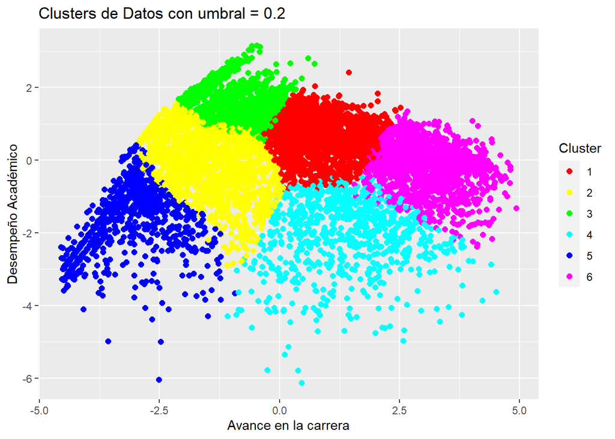

```r
ggplot() + geom_point(aes(x = Dim.1, y = Dim.2, color = as.factor(Clust_aum)), data = coord, size = 2) +
  scale_colour_manual(values=rainbow(6)) +
  ggtitle('Clusters de Datos con umbral = 0.2') +
  xlab('Avance en la carrera') + ylab('Desempeño Académico') +
  labs(color="Cluster")
```

De esta forma creamos el listado de estudiantes que requieren la atención por parte de sus profesores tutores

```r
BASE$GRUPO <- Clust_aum
activos <- which(BASE$ACTIVO=="1" & BASE$PAPA_tot>2.7)
BASE_act <- BASE[activos,]
```

Cargamos la información personal de los estudiantes

```r
library(sqldf)
load("Importacion2.RData")
INFO_actuales <- Importacion2("2023-2")
INFO_actuales <- unique(INFO_actuales)

BASE_act <- sqldf("SELECT B.*, F.PLAN
                   FROM BASE_act B INNER JOIN INFO_actuales F
                        ON (B.IDG_RIUU = F.IDG_RIUU)")
```

### 6.0.1 Triage 1

```r
Riesgo_Extremo <- BASE_act[which(BASE_act$GRUPO==5),c(1:3,11:12)]
Riesgo_Extremo$TRIAGE <- rep("I", nrow(Riesgo_Extremo))
nrow(Riesgo_Extremo)
```

```
## [1] 60
```

```r
head(Riesgo_Extremo)
```

```
##      IDG_RIUU COD_PLAN PAPA_tot GRUPO     PLAN TRIAGE
## 3   013972513     2513 2.744444     5 BIOLOGÍA      I
## 14  015892513     2513 2.967213     5 BIOLOGÍA      I
## 319 023812513     2513 3.084615     5 BIOLOGÍA      I
## 400 025092513     2513 3.086047     5 BIOLOGÍA      I
## 443 025612513     2513 2.835714     5 BIOLOGÍA      I
## 482 026192513     2513 2.720000     5 BIOLOGÍA      I
```

### 6.0.2 Triage 2

```r
Riesgo_Medio <- BASE_act[which(BASE_act$PAPA_tot<3.4 & BASE_act$GRUPO==2 ), c(1:3,11:12)]
Riesgo_Medio$TRIAGE <- rep("II", nrow(Riesgo_Medio))
nrow(Riesgo_Medio)
```

```
## [1] 409
```

```r
head(Riesgo_Medio)
```

```
##      IDG_RIUU COD_PLAN PAPA_tot GRUPO     PLAN TRIAGE
## 1   005352513     2513 3.107143     2 BIOLOGÍA     II
## 2   012412513     2513 2.942857     2 BIOLOGÍA     II
## 15  016452513     2513 3.262500     2 BIOLOGÍA     II
## 32  017902513     2513 3.395833     2 BIOLOGÍA     II
## 84  019862513     2513 2.957746     2 BIOLOGÍA     II
## 135 020812513     2513 3.116364     2 BIOLOGÍA     II
```

### 6.0.3 Triage 3

```r
Riesgo_Bajo <- BASE_act[which(BASE_act$PAPA_tot<3.4 & BASE_act$AVANCE<75 & BASE_act$GRUPO==4 ),c(1:3,11:12)]
Riesgo_Bajo$TRIAGE <- rep("III", nrow(Riesgo_Bajo))
nrow(Riesgo_Bajo)
```

```
## [1] 159
```

```r
head(Riesgo_Bajo)
```

```
##     IDG_RIUU COD_PLAN PAPA_tot GRUPO     PLAN TRIAGE
## 11 015652513     2513 3.133654     4 BIOLOGÍA    III
## 20 017052513     2513 3.277358     4 BIOLOGÍA    III
## 21 017122513     2513 2.841818     4 BIOLOGÍA    III
## 28 017622513     2513 3.194558     4 BIOLOGÍA    III
## 29 017712513     2513 2.904202     4 BIOLOGÍA    III
## 39 018212513     2513 2.934454     4 BIOLOGÍA    III
```

De esta forma, se crea un dataframe que contiene el listado de los estudiantes activos en el semestre con su respectivo nivel de triage académico y esta información se guardará en un archivo ‘csv’.

```r
Est_Riesgo <- rbind(Riesgo_Extremo, Riesgo_Medio, Riesgo_Bajo)
Est_Riesgo$PAPA_tot <- as.character(round(Est_Riesgo$PAPA_tot, 1))
head(Est_Riesgo)
```

```
##      IDG_RIUU COD_PLAN PAPA_tot GRUPO     PLAN TRIAGE
## 3   013972513     2513      2.7     5 BIOLOGÍA      I
## 14  015892513     2513        3     5 BIOLOGÍA      I
## 319 023812513     2513      3.1     5 BIOLOGÍA      I
## 400 025092513     2513      3.1     5 BIOLOGÍA      I
## 443 025612513     2513      2.8     5 BIOLOGÍA      I
## 482 026192513     2513      2.7     5 BIOLOGÍA      I
```

```r
write.csv(Est_Riesgo, file = "Est_Riesgo.csv", fileEncoding = "UTF-8")
```

# 7 Identificación de estudiantes sobresalientes

Para aprovechar el resultado del Triage Academico con respecto a los triage IV, V y VI, se decide enviar un correo de felicitaciones a los estudiantes clasificados dentro de estos niveles, con el fin de motivarlos a continuar con ese buen desempeño y que consigan culminar sus estudios.

### 7.0.1 Triage 4

```r
Consillium_Bajo <- BASE_act[which(BASE_act$GRUPO==3 & BASE_act$PAPA_tot>3.7),c(1:3,11:12)]
Consillium_Bajo$TRIAGE <- rep("IV", nrow(Consillium_Bajo))
nrow(Consillium_Bajo)
```

```
## [1] 541
```

```r
head(Consillium_Bajo)
```

```
##      IDG_RIUU COD_PLAN PAPA_tot GRUPO     PLAN TRIAGE
## 54  018782513     2513 3.848936     3 BIOLOGÍA     IV
## 210 022352513     2513 3.897778     3 BIOLOGÍA     IV
## 328 023912513     2513 3.980952     3 BIOLOGÍA     IV
## 350 024352513     2513 3.978431     3 BIOLOGÍA     IV
## 357 024482513     2513 4.409524     3 BIOLOGÍA     IV
## 377 024812513     2513 4.092308     3 BIOLOGÍA     IV
```

### 7.0.2 Triage 5

```r
Consillium_Medio <- BASE_act[which(BASE_act$GRUPO==1 & BASE_act$PAPA_tot>3.7),c(1:3,11:12)]
Consillium_Medio$TRIAGE <- rep("V", nrow(Consillium_Medio))
nrow(Consillium_Medio)
```

```
## [1] 685
```

```r
head(Consillium_Medio)
```

```
##     IDG_RIUU COD_PLAN PAPA_tot GRUPO     PLAN TRIAGE
## 4  014442513     2513 4.397260     1 BIOLOGÍA      V
## 19 016862513     2513 3.708000     1 BIOLOGÍA      V
## 26 017522513     2513 3.912632     1 BIOLOGÍA      V
## 36 018182513     2513 4.114286     1 BIOLOGÍA      V
## 58 018872513     2513 4.600000     1 BIOLOGÍA      V
## 74 019562513     2513 4.335185     1 BIOLOGÍA      V
```

### 7.0.3 Triage 6

```r
Consillium_Alto <- BASE_act[which(BASE_act$GRUPO==6 & BASE_act$PAPA_tot>3.7),c(1:3,11:12)]
Consillium_Alto$TRIAGE <- rep("VI", nrow(Consillium_Alto))
nrow(Consillium_Alto)
```

```
## [1] 581
```

```r
head(Consillium_Alto)
```

```
##     IDG_RIUU COD_PLAN PAPA_tot GRUPO     PLAN TRIAGE
## 17 016572513     2513 4.021088     6 BIOLOGÍA     VI
## 22 017162513     2513 3.828777     6 BIOLOGÍA     VI
## 27 017552513     2513 3.739416     6 BIOLOGÍA     VI
## 33 017942513     2513 3.793793     6 BIOLOGÍA     VI
## 34 017972513     2513 3.959200     6 BIOLOGÍA     VI
## 35 018122513     2513 3.847761     6 BIOLOGÍA     VI
```

De esta forma, se crea un dataframe que contiene el listado de los estudiantes activos en el semestre con su respectivo nivel de triage académico y esta información se guardará en un archivo ‘csv’.

```r
Est_Buenos <- rbind(Consillium_Bajo, Consillium_Medio, Consillium_Alto)
Est_Buenos$PAPA_tot <- as.character(round(Est_Buenos$PAPA_tot, 1))
head(Est_Buenos)
```

```
##      IDG_RIUU COD_PLAN PAPA_tot GRUPO     PLAN TRIAGE
## 54  018782513     2513      3.8     3 BIOLOGÍA     IV
## 210 022352513     2513      3.9     3 BIOLOGÍA     IV
## 328 023912513     2513        4     3 BIOLOGÍA     IV
## 350 024352513     2513        4     3 BIOLOGÍA     IV
## 357 024482513     2513      4.4     3 BIOLOGÍA     IV
## 377 024812513     2513      4.1     3 BIOLOGÍA     IV
```

```r
write.csv(Est_Buenos, file = "Est_Buenos.csv", fileEncoding = "UTF-8")
```